# BRICS Challenge

## Selection of Data Sets

#### 1. Web Traffic

- Super Messy
- Try to avoid
- NO

#### 2. Wallmart

- Sales Data
- Fairly Clean
- Yes - Good variety of data

#### 3. Titanic

- Personal Information
- Survival Information
- Ehhh

#### 4. TaxiFare

- Location Data
- Maybe, understanding location data

#### 5. Movie Sentiment

- Cannot see yet
- Fairly Empty
- No

#### 6. Meteorite

- Locations, etc
- Maybe, understanding location data

#### 7. Lending Club

- Loans with personal data
- Maybe, boring

#### 8. Machine Performance

- Nothing understandable
- NO

#### 9. IMDB Ratings

- Very Clean
- Titles, Year, Actor, Ratings
- Maybe

#### 10. Movie Songs

- LEarning curve to read
- NO

#### 11. Nutrition

- Difficult to understand
- A lot going on
- NO

### Selection

Maaking use of a comparison between the **Wallmart** and **Taxi Data** by correlating the *dates*

## Data Prep

### Data Sets

- WalmartFeatures
- TaxiFares
- TaxiTrain
- TaxiTest

#### WalmartFeatures

Only keeping: - Date - Temperature - Fuel_Price - CPI - Unemployment - IsHoliday

```r
library(dplyr)
library(readr)
library(rworldmap)
```

```r
library(ggplot2)
library(rpart)
library(rattle)
library(descr)
WallmartFeatures <- read.csv("C:/Users/GoRentals/Desktop/FlashDrive/DATA SETS/2. Walmart Dataset/features.csv")
orgData <- WallmartFeatures
head(WallmartFeatures)
```

```
##   Store       Date Temperature Fuel_Price MarkDown1 MarkDown2 MarkDown3
## 1     1 2010-02-05       42.31      2.572        NA        NA        NA
## 2     1 2010-02-12       38.51      2.548        NA        NA        NA
## 3     1 2010-02-19       39.93      2.514        NA        NA        NA
## 4     1 2010-02-26       46.63      2.561        NA        NA        NA
## 5     1 2010-03-05       46.50      2.625        NA        NA        NA
## 6     1 2010-03-12       57.79      2.667        NA        NA        NA
##   MarkDown4 MarkDown5      CPI Unemployment IsHoliday
## 1        NA        NA 211.0964        8.106     FALSE
## 2        NA        NA 211.2422        8.106      TRUE
## 3        NA        NA 211.2891        8.106     FALSE
## 4        NA        NA 211.3196        8.106     FALSE
## 5        NA        NA 211.3501        8.106     FALSE
## 6        NA        NA 211.3806        8.106     FALSE
```

##### Delete unwanted columns

```r
WallmartFeatures$Store <- NULL
WallmartFeatures$MarkDown1 <- NULL
WallmartFeatures$MarkDown2 <- NULL
WallmartFeatures$MarkDown3 <- NULL
WallmartFeatures$MarkDown4 <- NULL
WallmartFeatures$MarkDown5 <- NULL

head(WallmartFeatures)
```

```
##         Date Temperature Fuel_Price      CPI Unemployment IsHoliday
## 1 2010-02-05       42.31      2.572 211.0964        8.106     FALSE
## 2 2010-02-12       38.51      2.548 211.2422        8.106      TRUE
## 3 2010-02-19       39.93      2.514 211.2891        8.106     FALSE
## 4 2010-02-26       46.63      2.561 211.3196        8.106     FALSE
## 5 2010-03-05       46.50      2.625 211.3501        8.106     FALSE
## 6 2010-03-12       57.79      2.667 211.3806        8.106     FALSE
```

##### Date

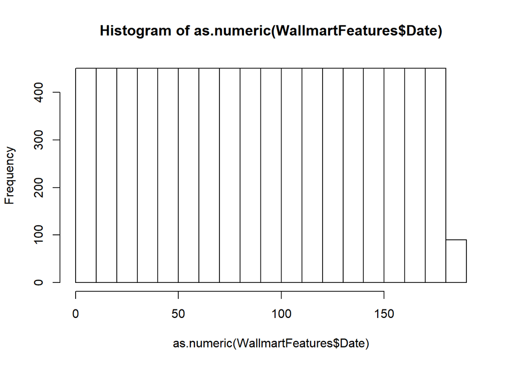

```r
hist(as.numeric(WallmartFeatures$Date))
```

```r
# max(as.numeric(WallmartFeatures$Date))

date <- as.Date(WallmartFeatures$Date)
# sort(date)
```

The frequency of mesurements for each date appears to be the same

###### Date Range

```r
head(sort(date))[1]
```

```
## [1] "2010-02-05"
```

```r
tail(sort(date))[1]
```

```
## [1] "2013-07-26"
```

##### Temperature

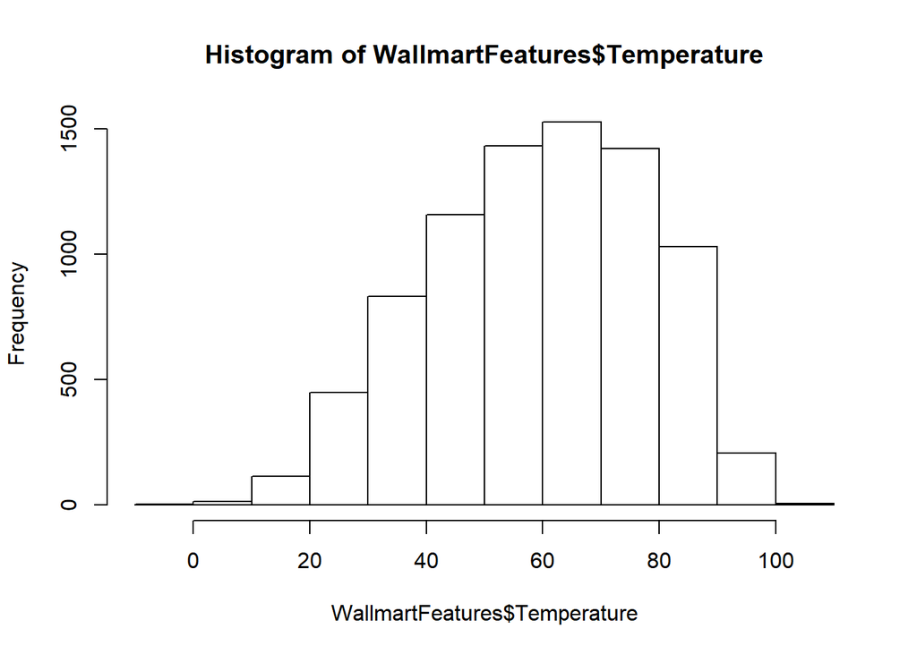

```r
hist(WallmartFeatures$Temperature)
```

Temperatures appear to be normally distributed

##### Fuel Price

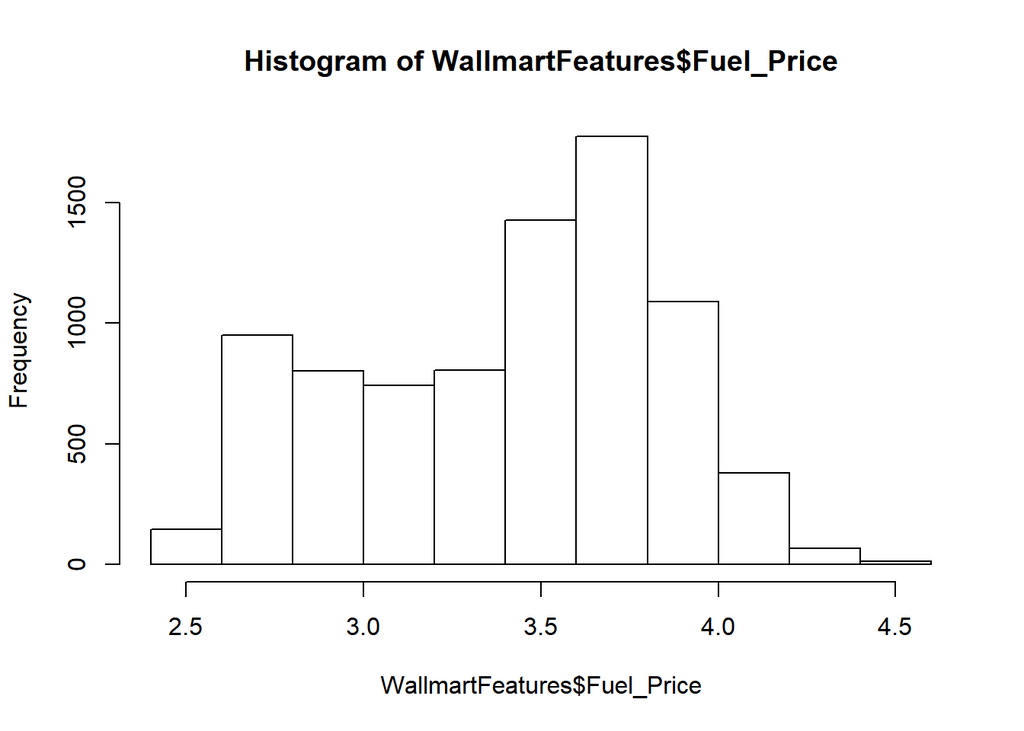

```r
hist(WallmartFeatures$Fuel_Price)
```

##### CPI

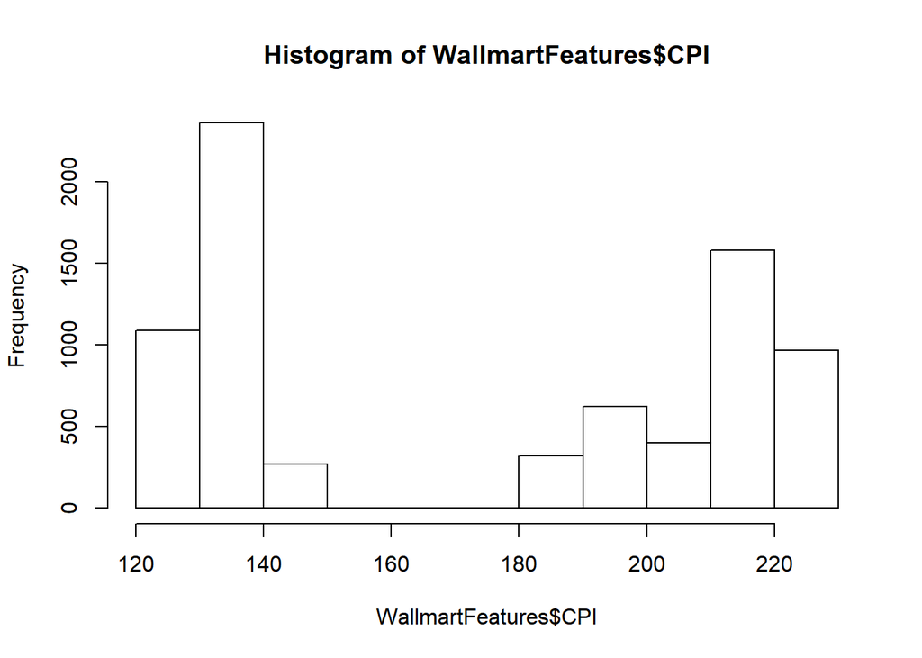

```r
hist(WallmartFeatures$CPI)
```

CPI is not normally distributed

##### Unemployment Rate

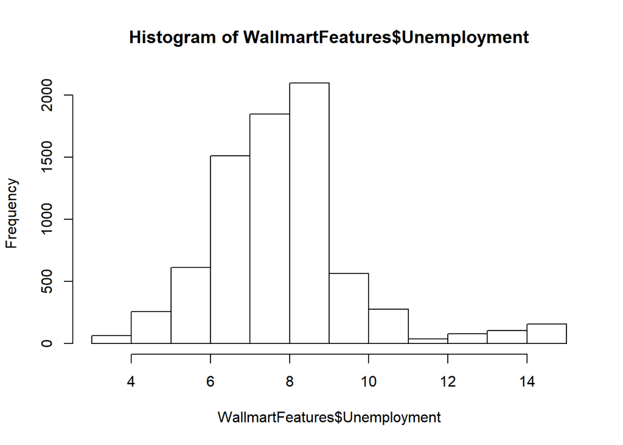

```r
hist(WallmartFeatures$Unemployment)
```

##### Holidays

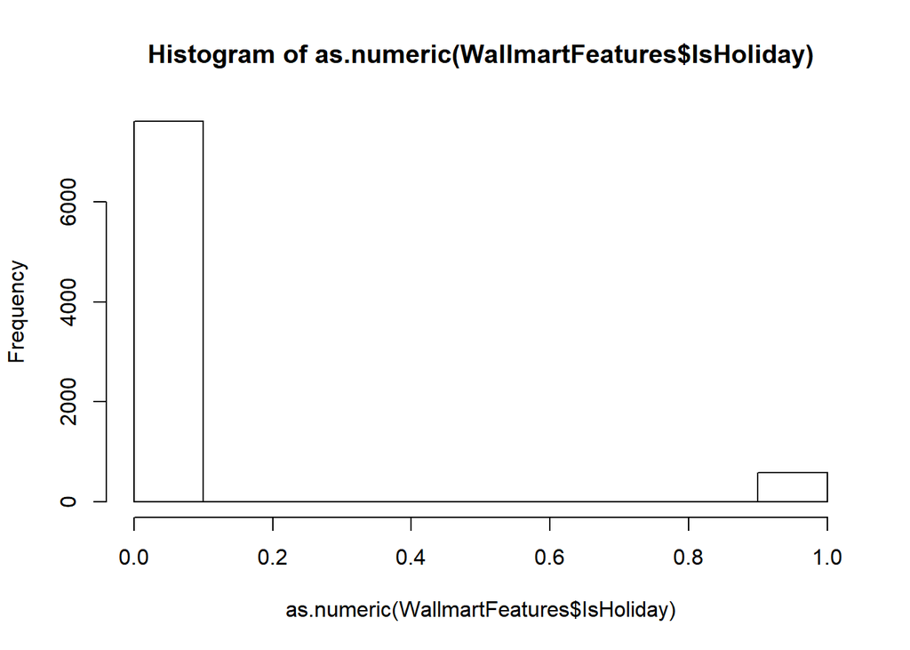

```r
hist(as.numeric(WallmartFeatures$IsHoliday))
```

Class Imbalance is visible here

##### Creating weekly buckets

```r
WallmartFeatures$WeekNo <- as.numeric(strftime(WallmartFeatures$Date, format = "%V"))
head(WallmartFeatures)
```

```
##         Date Temperature Fuel_Price      CPI Unemployment IsHoliday WeekNo
## 1 2010-02-05       42.31      2.572 211.0964        8.106     FALSE      5
## 2 2010-02-12       38.51      2.548 211.2422        8.106      TRUE      6
## 3 2010-02-19       39.93      2.514 211.2891        8.106     FALSE      7
## 4 2010-02-26       46.63      2.561 211.3196        8.106     FALSE      8
## 5 2010-03-05       46.50      2.625 211.3501        8.106     FALSE      9
## 6 2010-03-12       57.79      2.667 211.3806        8.106     FALSE     10
```

##### Creating aggregation table to join with taxi data on weekNo

```r
rm(WeeklyFeatures)
WeeklyFeatures <- as.data.frame(WallmartFeatures %>% group_by(WeekNo)
                                %>% summarize(
                                  AvgTemp = mean(Temperature)
                                  , AvgFuelPrice = mean(Fuel_Price)
                                  , AvgCPI = mean(CPI)
                                  , AvgUnemployment = mean(Unemployment)
                                  , ContainsHoliday = max(as.numeric(IsHoliday))
                                  ))
head(WeeklyFeatures)
```

```
##   WeekNo  AvgTemp AvgFuelPrice   AvgCPI AvgUnemployment ContainsHoliday
## 1      1 35.68941     3.242504 173.2724        7.558659               0
## 2      2 36.15711     3.284378 173.3760        7.558659               0
## 3      3 37.25400     3.294252 173.4923        7.558659               0
## 4      4 38.07622     3.295563 173.6019        7.558659               0
## 5      5 38.01961     3.174667 172.2163        7.823822               0
## 6      6 36.83144     3.230061 172.3222        7.823822               1
```

#### Taxi Test, Train & Fares

```r
TaxiTest <- read.csv("C:/Users/GoRentals/Desktop/FlashDrive/DATA SETS/4. Taxi Fare Dataset/test.csv")
#TaxiTrain <- read.csv("C:/Users/GoRentals/Desktop/FlashDrive/DATA SETS/4. Taxi Fare Dataset/train.csv")
# Taxi Train chunk
TaxiTrain_MIN <- read.csv("C:/Users/GoRentals/Desktop/FlashDrive/DATA SETS/4. Taxi Fare Dataset/train.csv"
                          , nrows=10000)
TaxiFares <- read.csv("C:/Users/GoRentals/Desktop/FlashDrive/DATA SETS/4. Taxi Fare Dataset/sample_submission.csv")
```

#### Taxi data plots

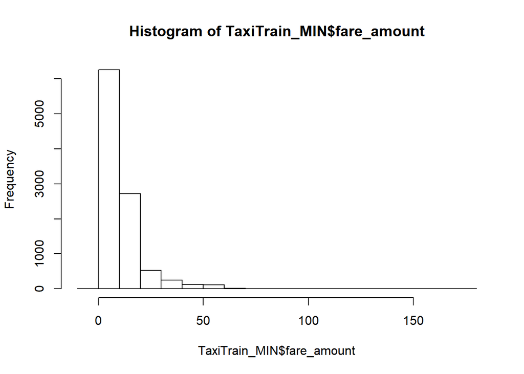

```r
hist(TaxiTrain_MIN$fare_amount)
```

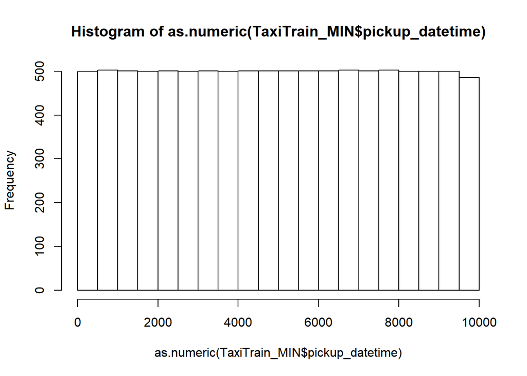

```r
hist(as.numeric(TaxiTrain_MIN$pickup_datetime))
```

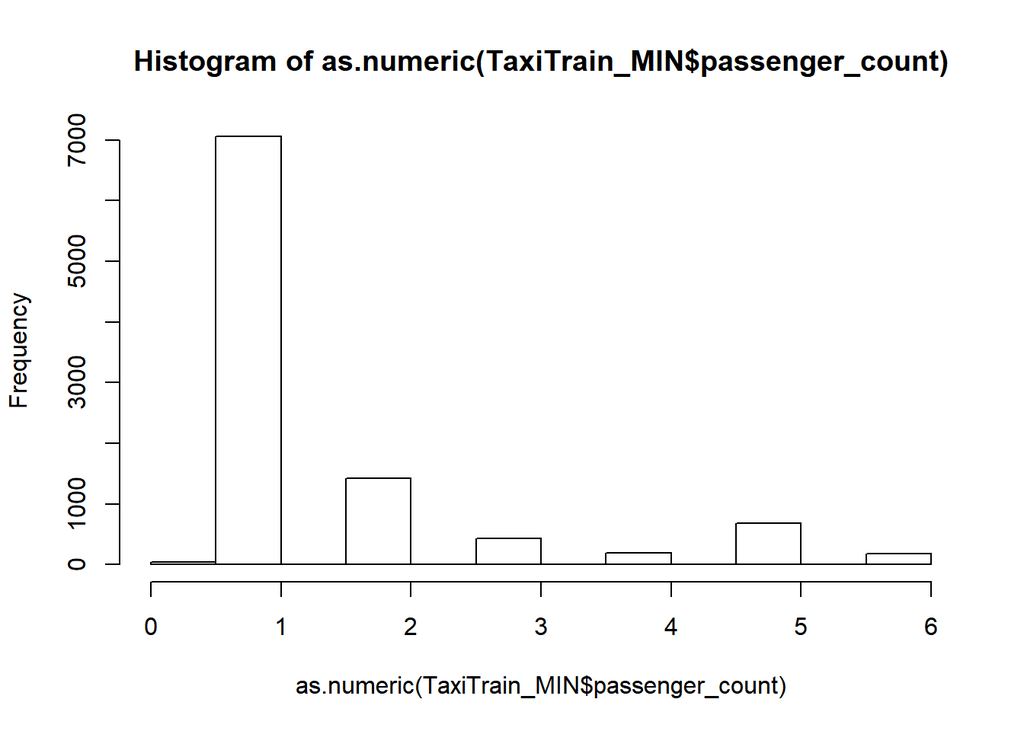

```r
hist(as.numeric(TaxiTrain_MIN$passenger_count))
```

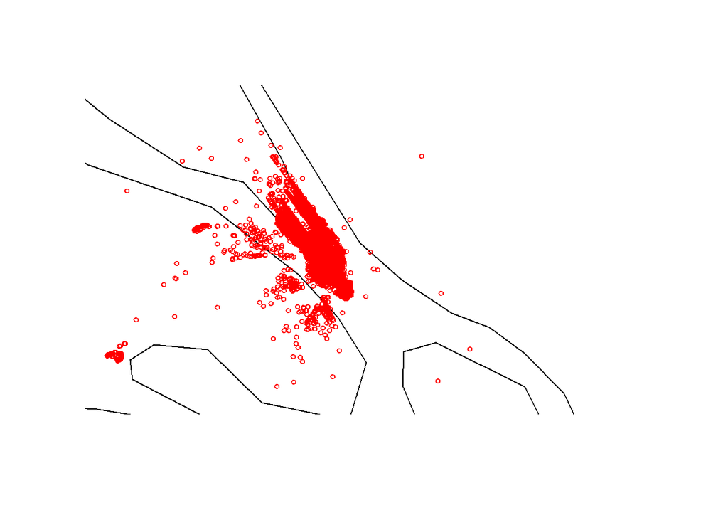

```r
TaxiTrain_MIN <- TaxiTrain_MIN[!TaxiTrain_MIN$fare_amount < 1, ]
TaxiTrain_MIN <- TaxiTrain_MIN[!TaxiTrain_MIN$passenger_count < 1, ]

pickUpMap <- getMap(resolution = "low")
plot(pickUpMap
     #, xlim = c(min(TaxiTrain_MIN$pickup_longitude), max(TaxiTrain_MIN$pickup_longitude))
     #, ylim = c(min(TaxiTrain_MIN$pickup_latitude), max(TaxiTrain_MIN$pickup_latitude))
     , xlim = c(-73.9, -74.2)
     , ylim = c(40.6, 40.9)
     , asp = 1)
points(TaxiTrain_MIN$pickup_longitude, TaxiTrain_MIN$pickup_latitude, col = "red", cex = .6)
```

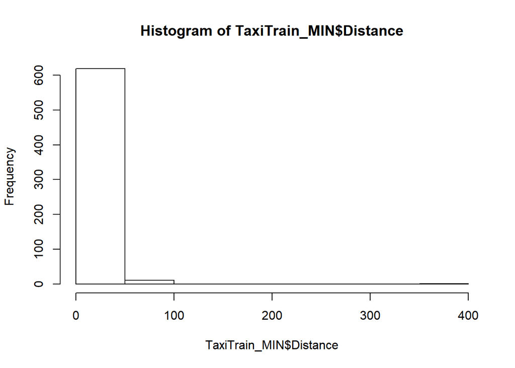

```r
TaxiTrain_MIN$Distance <- sqrt((TaxiTrain_MIN$dropoff_longitude - TaxiTrain_MIN$pickup_longitude)^2
                               +
                                 (TaxiTrain_MIN$dropoff_latitude - TaxiTrain_MIN$pickup_latitude)^2
                               )
TaxiTrain_MIN <- TaxiTrain_MIN[!TaxiTrain_MIN$Distance < 0.1, ]
hist(TaxiTrain_MIN$Distance)
```

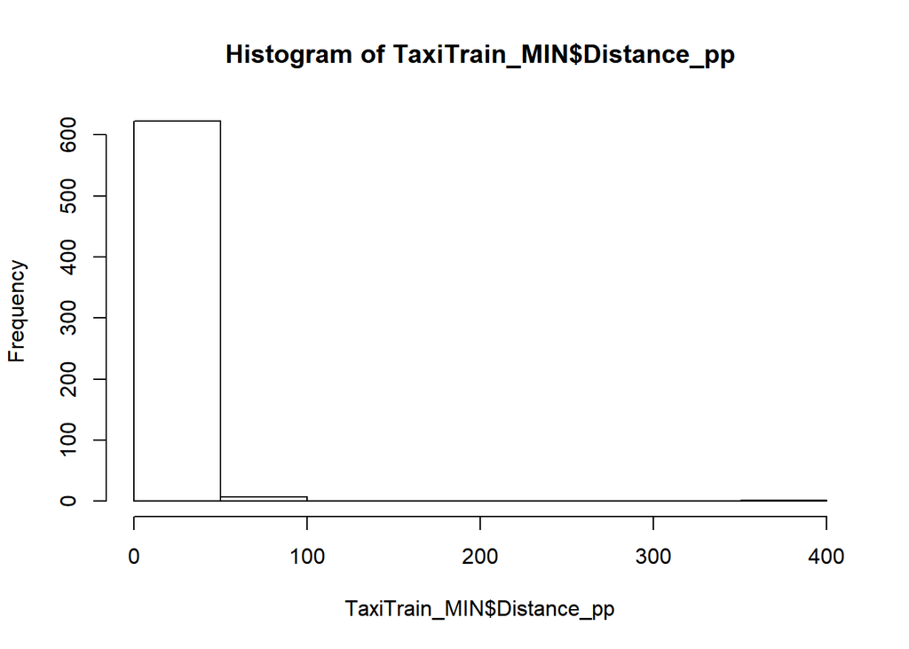

```r
TaxiTrain_MIN$Distance_pp <- TaxiTrain_MIN$Distance / TaxiTrain_MIN$passenger_count
hist(TaxiTrain_MIN$Distance_pp)
```

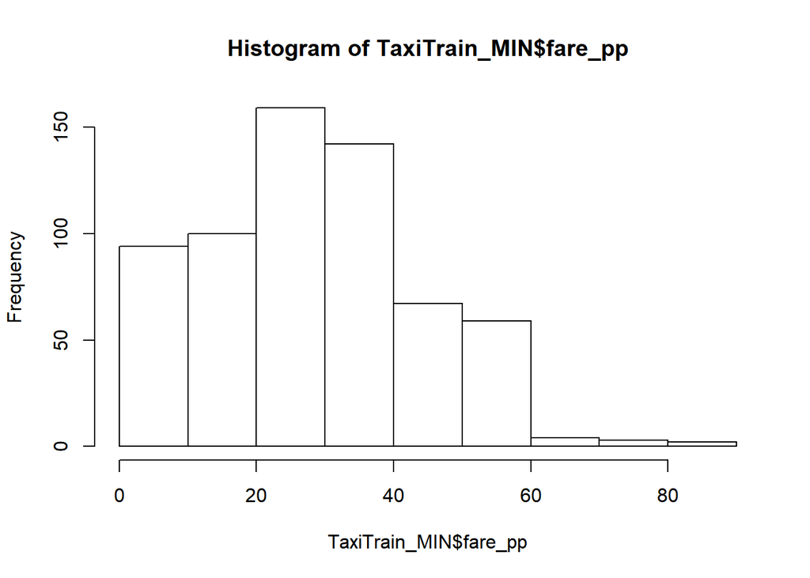

```r
TaxiTrain_MIN$fare_pp <- TaxiTrain_MIN$fare_amount / TaxiTrain_MIN$passenger_count
hist(TaxiTrain_MIN$fare_pp)
```

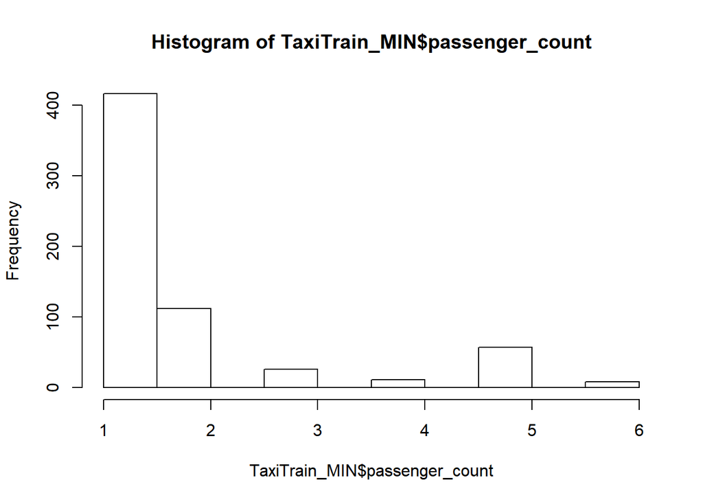

```r
hist(TaxiTrain_MIN$passenger_count)
```

###### Date Range

```r
head(sort(TaxiTrain_MIN$pickup_datetime))[1]
```

```
## [1] 2009-01-04 04:00:57 UTC
## 9985 Levels: 2009-01-01 02:51:52 UTC ... 2015-06-30 22:42:39 UTC
```

```r
tail(sort(TaxiTrain_MIN$pickup_datetime))[1]
```

```
## [1] 2015-06-11 00:13:16 UTC
## 9985 Levels: 2009-01-01 02:51:52 UTC ... 2015-06-30 22:42:39 UTC
```

#### Set the WeekNo per ride

```r
TaxiTrain_MIN$WeekNo <- as.numeric(strftime(TaxiTrain_MIN$pickup_datetime, format = "%V"))
```

#### Join Taxi data with Wallmart Weekly Features

```r
dfFeatures <- merge(TaxiTrain_MIN, WeeklyFeatures, by = "WeekNo")
head(dfFeatures)
```

```
##   WeekNo                           key fare_amount         pickup_datetime
## 1      1   2009-01-04 04:00:57.0000005        25.8 2009-01-04 04:00:57 UTC
## 2      1  2011-01-09 03:41:00.00000033        23.7 2011-01-09 03:41:00 UTC
## 3      1 2010-01-09 22:36:00.000000277        24.5 2010-01-09 22:36:00 UTC
## 4      1   2014-01-05 19:54:38.0000004        26.5 2014-01-05 19:54:38 UTC
## 5      1 2014-01-01 15:10:00.000000147        33.0 2014-01-01 15:10:00 UTC
## 6      1   2012-12-31 02:07:22.0000001        39.0 2012-12-31 02:07:22 UTC
##   pickup_longitude pickup_latitude dropoff_longitude dropoff_latitude
## 1        -73.99298        40.73401         -73.93768         40.84980
## 2        -73.95641        40.77148         -73.90467         40.88535
## 3        -73.97432        40.67988         -73.97290         40.79083
## 4        -74.00878        40.70499         -73.92933         40.76707
## 5        -73.98610        40.75992         -73.86359         40.73733
## 6        -73.78264        40.64443         -73.98737         40.68623
##   passenger_count  Distance Distance_pp fare_pp  AvgTemp AvgFuelPrice
## 1               1 0.1283114   0.1283114    25.8 35.68941     3.242504
## 2               1 0.1250776   0.1250776    23.7 35.68941     3.242504
## 3               1 0.1109561   0.1109561    24.5 35.68941     3.242504
## 4               1 0.1008308   0.1008308    26.5 35.68941     3.242504
## 5               1 0.1245811   0.1245811    33.0 35.68941     3.242504
## 6               1 0.2089523   0.2089523    39.0 35.68941     3.242504
##     AvgCPI AvgUnemployment ContainsHoliday
## 1 173.2724        7.558659               0
## 2 173.2724        7.558659               0
## 3 173.2724        7.558659               0
## 4 173.2724        7.558659               0
## 5 173.2724        7.558659               0
## 6 173.2724        7.558659               0
```

#### Run PCA and analyse results

Version 1

```r
dPCA.Features <- dfFeatures
dPCA.Features$pickup_datetime <- NULL
dPCA.Features$key <- NULL


dPCA <- prcomp(na.omit(dPCA.Features), center = TRUE, scale. = TRUE)
print(dPCA)
```

```
## Standard deviations (1, .., p=15):
##  [1] 1.977578882 1.663302268 1.404404129 1.352010580 1.198535542
##  [6] 0.994807468 0.874128708 0.836798619 0.523220706 0.409466351
## [11] 0.296745515 0.256341855 0.190176281 0.021405848 0.006679732
##
## Rotation (n x k) = (15 x 15):
##                            PC1           PC2           PC3         PC4
## WeekNo             0.082763488  0.2808303548 -0.0007716283  0.01324307
## fare_amount        0.202138292 -0.0131724637  0.1788170995  0.42443115
## pickup_longitude  -0.343305983  0.0343967043 -0.4233816423  0.30653740
## pickup_latitude    0.343086780 -0.0340696885  0.4222832554 -0.30844844
## dropoff_longitude -0.350203231 -0.0119229431  0.4500884671 -0.15589836
## dropoff_latitude   0.307851987  0.0345314520 -0.4444640555  0.14402873
## passenger_count   -0.028716879 -0.0486088646 -0.2782906855 -0.44146881
## Distance          -0.494858532  0.0139244013  0.0391974621  0.09934415
## Distance_pp       -0.471557647  0.0003347842  0.1235903083  0.07435342
## fare_pp            0.162325376  0.0228147672  0.2950474070  0.60647547
## AvgTemp            0.008420229  0.5346021099  0.0608654328 -0.03234855
## AvgFuelPrice      -0.060262451  0.1072472698  0.1429610533  0.00484265
## AvgCPI             0.002909062 -0.5536389152  0.0202873031  0.03665082
## AvgUnemployment   -0.013056915  0.5564009705 -0.0060416825 -0.04324430
## ContainsHoliday    0.031629938  0.0283817863 -0.0664871293 -0.05604015
##                            PC5          PC6          PC7          PC8
## WeekNo             0.320385382 -0.478038840  0.504749738 -0.505123325
## fare_amount        0.009326767 -0.518707288 -0.444485134  0.092612054
## pickup_longitude  -0.029739220 -0.025958187 -0.014219265 -0.037814263
## pickup_latitude    0.029348759  0.029627440  0.015717327  0.038598444
## dropoff_longitude  0.102965332 -0.064600264 -0.008650749  0.044534382
## dropoff_latitude  -0.082143090  0.096103674  0.065706645  0.001612451
## passenger_count   -0.058865289 -0.581679784 -0.397221914  0.050032142
## Distance           0.053909865 -0.069380844 -0.021121961  0.004095742
## Distance_pp        0.058364447 -0.043468523 -0.001382601 -0.008761054
## fare_pp            0.060200723 -0.005173767 -0.051054908  0.016885815
## AvgTemp           -0.252106660 -0.039760476  0.033653259 -0.198408944
## AvgFuelPrice      -0.677473049  0.110066879 -0.244900244 -0.503052585
## AvgCPI            -0.107208485 -0.110003602  0.113188023 -0.354226240
## AvgUnemployment    0.077527550  0.066674374 -0.144959415  0.227364665
## ContainsHoliday    0.569857429  0.334869621 -0.535766660 -0.508809350
##                            PC9         PC10         PC11         PC12
## WeekNo             0.001343171  0.197277801 -0.002153094 -0.009315924
```

[output cut: 15 more lines]

```
## WeekNo            -0.1843992030  1.954098e-03  3.202552e-04
## fare_amount       -0.0067532828  2.299665e-03 -2.391491e-04
## pickup_longitude   0.0015537909  5.577698e-01 -5.104940e-01
## pickup_latitude    0.0019613499  7.555401e-01 -1.407404e-02
## dropoff_longitude -0.0157205792 -1.883428e-01 -4.753891e-01
## dropoff_latitude  -0.0101709916  2.172447e-02  5.376391e-02
## passenger_count   -0.0001744487  9.612836e-04 -1.063002e-03
## Distance          -0.0076903699  2.865037e-01  7.143573e-01
## Distance_pp        0.0222686734 -1.592611e-03 -7.131245e-04
## fare_pp            0.0209843969  9.564348e-04 -1.670845e-03
## AvgTemp            0.4141258282 -2.236766e-03 -9.411378e-04
## AvgFuelPrice      -0.2880293838  1.557455e-03  5.725235e-04
## AvgCPI             0.7091313258 -1.037047e-03  8.670211e-05
## AvgUnemployment    0.4550656219 -8.443536e-04 -3.550249e-05
## ContainsHoliday    0.0136376024  6.203282e-05  3.988606e-04
```

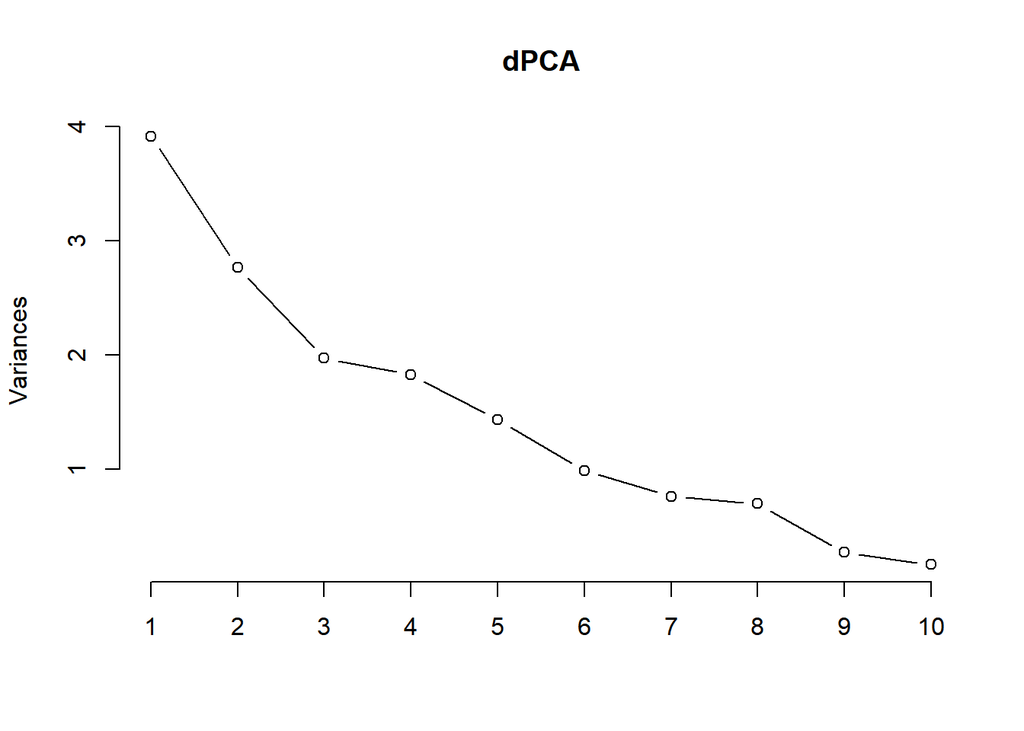

```r
plot(dPCA, type = "l")
```

```r
summary(dPCA)
```

```
## Importance of components:
##                           PC1    PC2    PC3    PC4     PC5     PC6     PC7
## Standard deviation     1.9776 1.6633 1.4044 1.3520 1.19854 0.99481 0.87413
## Proportion of Variance 0.2607 0.1844 0.1315 0.1219 0.09577 0.06598 0.05094
## Cumulative Proportion  0.2607 0.4452 0.5766 0.6985 0.79428 0.86025 0.91119
##                            PC8     PC9    PC10    PC11    PC12    PC13
## Standard deviation     0.83680 0.52322 0.40947 0.29675 0.25634 0.19018
## Proportion of Variance 0.04668 0.01825 0.01118 0.00587 0.00438 0.00241
## Cumulative Proportion  0.95788 0.97613 0.98730 0.99317 0.99756 0.99997
##                           PC14    PC15
## Standard deviation     0.02141 0.00668
## Proportion of Variance 0.00003 0.00000
## Cumulative Proportion  1.00000 1.00000
```

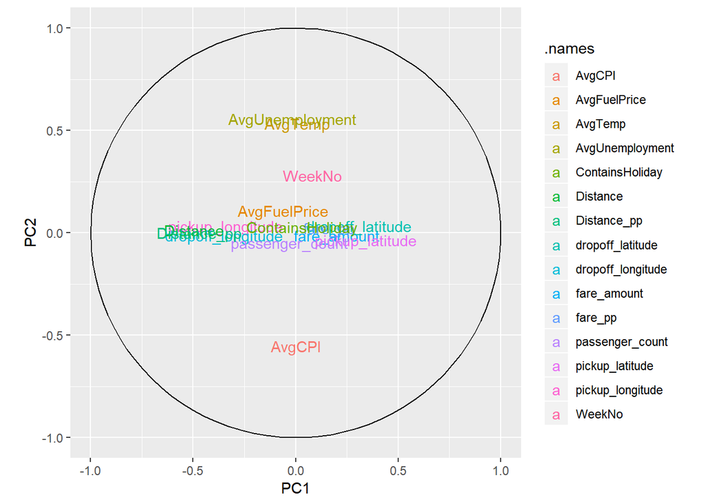

```r
#Draw circle of trust
#Positively correlated is grouped together
theta <- seq(0, 2*pi, length.out = 100)
circle <- data.frame(x = cos(theta), y = sin(theta))
p <- ggplot(circle, aes(x, y)) + geom_path()
loadings <- data.frame(dPCA$rotation, .names = row.names(dPCA$rotation))
p + geom_text(data = loadings
        , mapping = aes(x = PC1, y = PC2, label = .names, colour = .names)) +
        coord_fixed(ratio=1) +
        labs(x="PC1", y="PC2")
```

Version 2

```r
dPCA.Features <- dfFeatures
dPCA.Features$pickup_datetime <- NULL
dPCA.Features$key <- NULL
dPCA.Features$dropoff_latitude <- NULL
dPCA.Features$dropoff_longitude  <- NULL
dPCA.Features$pickup_latitude  <- NULL
dPCA.Features$pickup_longitude  <- NULL

dPCA <- prcomp(na.omit(dPCA.Features), center = TRUE, scale. = TRUE)
print(dPCA)
```

```
## Standard deviations (1, .., p=11):
##  [1] 1.6625167 1.5270434 1.3083334 1.1884899 0.9804625 0.8713649 0.8391209
##  [8] 0.4091330 0.2995158 0.2488319 0.1902834
##
## Rotation (n x k) = (11 x 11):
##                          PC1         PC2         PC3           PC4
## WeekNo           0.286553875  0.12754077  0.13159068 -0.2646674628
## fare_amount      0.003162869  0.44769255 -0.24630833 -0.0003030625
## passenger_count -0.056346075 -0.20109878  0.50398160  0.1854934308
## Distance        -0.012412080 -0.51440103 -0.37343720 -0.2149572463
## Distance_pp     -0.021962987 -0.50082986 -0.40215540 -0.2168147360
## fare_pp          0.038990100  0.45740694 -0.50312699 -0.1376664727
## AvgTemp          0.535877240 -0.03508842 -0.05379092  0.2538946240
## AvgFuelPrice     0.106624632 -0.10177958 -0.25866389  0.6367920087
## AvgCPI          -0.552309969  0.04434997 -0.04938870  0.1087902452
## AvgUnemployment  0.555052973 -0.05672555  0.03747689 -0.0783599828
## ContainsHoliday  0.029698464  0.03780143  0.20013331 -0.5435382024
##                         PC5         PC6          PC7          PC8
## WeekNo           0.49356638 -0.50578089  0.491938801 -0.196522334
## fare_amount      0.49225390  0.47306570 -0.061719634  0.011798565
## passenger_count  0.52215199  0.41721863 -0.021433602  0.047468528
## Distance         0.20509858  0.08112020  0.005099035  0.057650483
## Distance_pp      0.18698663  0.06535766  0.036122852 -0.001438966
## fare_pp          0.02585682  0.05820616 -0.017560107  0.039164773
## AvgTemp          0.02243890 -0.04617113  0.195457280  0.656070560
## AvgFuelPrice    -0.14666649  0.21234226  0.510023004 -0.308626252
## AvgCPI           0.10547155 -0.12490473  0.350383018 -0.156772767
## AvgUnemployment -0.06394849  0.15407190 -0.219499612 -0.629924101
## ContainsHoliday -0.35568160  0.49550250  0.531801592  0.084060452
##                           PC9         PC10         PC11
## WeekNo           0.0010994372 -0.015170481  0.184328543
## fare_amount     -0.4852883317 -0.182485112  0.005859230
## passenger_count  0.4262743560  0.191941383  0.001028836
## Distance         0.2508159063 -0.659294841 -0.001326963
## Distance_pp     -0.2568127767  0.658333907 -0.007113311
## fare_pp          0.6710509495  0.246072798 -0.020245325
## AvgTemp         -0.0416927127  0.010127748 -0.413690927
## AvgFuelPrice     0.0324557496 -0.014477487  0.287444152
## AvgCPI          -0.0003895842 -0.023976031 -0.709975925
## AvgUnemployment  0.0277858536 -0.008098600 -0.455526016
## ContainsHoliday -0.0070383551 -0.007063863 -0.013830298
```

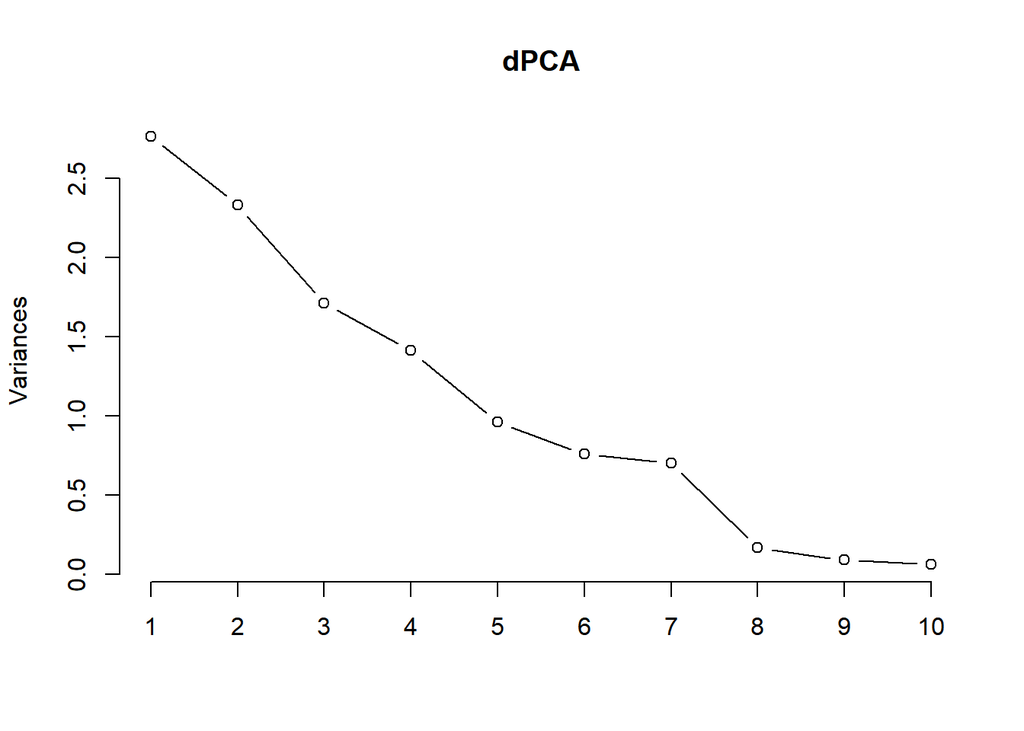

```r
plot(dPCA, type = "l")
```

```r
summary(dPCA)
```

```
## Importance of components:
##                           PC1    PC2    PC3    PC4     PC5     PC6     PC7
## Standard deviation     1.6625 1.5270 1.3083 1.1885 0.98046 0.87136 0.83912
## Proportion of Variance 0.2513 0.2120 0.1556 0.1284 0.08739 0.06903 0.06401
## Cumulative Proportion  0.2513 0.4633 0.6189 0.7473 0.83467 0.90370 0.96771
##                            PC8     PC9    PC10    PC11
## Standard deviation     0.40913 0.29952 0.24883 0.19028
## Proportion of Variance 0.01522 0.00816 0.00563 0.00329
## Cumulative Proportion  0.98292 0.99108 0.99671 1.00000
```

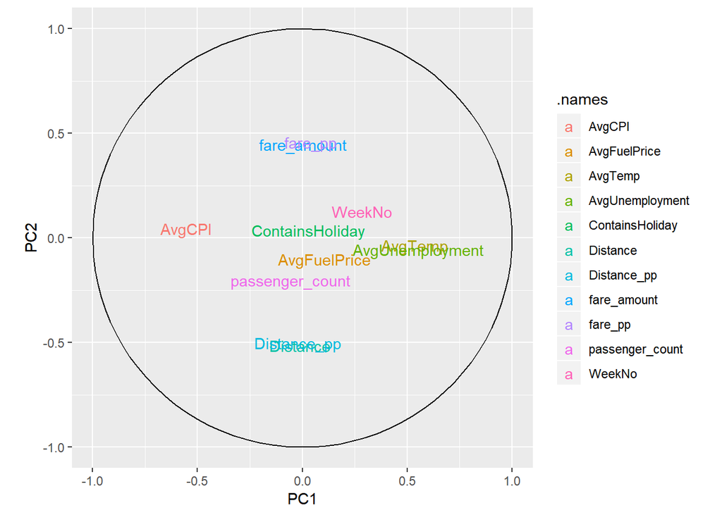

```r
#Draw circle of trust
#Positively correlated is grouped together
theta <- seq(0, 2*pi, length.out = 100)
circle <- data.frame(x = cos(theta), y = sin(theta))
p <- ggplot(circle, aes(x, y)) + geom_path()
loadings <- data.frame(dPCA$rotation, .names = row.names(dPCA$rotation))
p + geom_text(data = loadings
        , mapping = aes(x = PC1, y = PC2, label = .names, colour = .names)) +
        coord_fixed(ratio=1) +
        labs(x="PC1", y="PC2")
```

```r
dtDataSet <- dPCA.Features
dtDataSet$Distance <- NULL
dtDataSet$fare_amount <- NULL

fitPerPerson <- rpart(dtDataSet$passenger_count ~ ., data = dtDataSet)
summary(fitPerPerson)
```

```
## Call:
## rpart(formula = dtDataSet$passenger_count ~ ., data = dtDataSet)
##   n= 628
##
##           CP nsplit rel error    xerror       xstd
## 1 0.80572615      0 1.0000000 1.0019722 0.08116576
## 2 0.07158917      1 0.1942738 0.2065514 0.02149279
## 3 0.01613107      2 0.1226847 0.1363179 0.02023836
## 4 0.01000000      3 0.1065536 0.1240109 0.01854576
##
## Variable importance
## Distance_pp     fare_pp
##          62          38
##
## Node number 1: 628 observations,    complexity param=0.8057262
##   mean=1.738854, MSE=1.724796
##   left son=2 (540 obs) right son=3 (88 obs)
##   Primary splits:
##       Distance_pp  < 0.04924904 to the right, improve=0.805726200, (0 missing)
##       fare_pp      < 11.91667   to the right, improve=0.591607600, (0 missing)
##       AvgFuelPrice < 3.588539   to the left,  improve=0.018711560, (0 missing)
##       AvgCPI       < 172.8015   to the left,  improve=0.006357240, (158 missing)
##       WeekNo       < 48.5       to the left,  improve=0.005700125, (0 missing)
##   Surrogate splits:
##       fare_pp < 11.16667   to the right, agree=0.943, adj=0.591, (0 split)
##
## Node number 2: 540 observations,    complexity param=0.07158917
##   mean=1.262963, MSE=0.2715912
##   left son=4 (458 obs) right son=5 (82 obs)
##   Primary splits:
##       Distance_pp  < 0.09870855 to the right, improve=0.528731600, (0 missing)
##       fare_pp      < 19.275     to the right, improve=0.394405700, (0 missing)
##       AvgTemp      < 80.53689   to the left,  improve=0.017072260, (0 missing)
##       AvgCPI       < 171.9053   to the right, improve=0.016474330, (136 missing)
##       AvgFuelPrice < 3.368894   to the right, improve=0.005132018, (0 missing)
##   Surrogate splits:
##       fare_pp < 19.275     to the right, agree=0.926, adj=0.512, (0 split)
##
## Node number 3: 88 observations,    complexity param=0.01613107
##   mean=4.659091, MSE=0.7246901
##   left son=6 (8 obs) right son=7 (80 obs)
##   Primary splits:
##       fare_pp      < 11.62133   to the right, improve=0.27398430, (0 missing)
##       Distance_pp  < 0.02621089 to the right, improve=0.23412240, (0 missing)
##       WeekNo       < 30         to the right, improve=0.06800446, (0 missing)
##       AvgFuelPrice < 3.586017   to the left,  improve=0.05176088, (0 missing)
##       AvgCPI       < 172.0398   to the left,  improve=0.05074391, (22 missing)
##
## Node number 4: 458 observations
##   mean=1.10262, MSE=0.1226569
##
## Node number 5: 82 observations
##   mean=2.158537, MSE=0.157793
##
## Node number 6: 8 observations
##   mean=3.25, MSE=0.1875
##
## Node number 7: 80 observations
##   mean=4.8, MSE=0.56
```

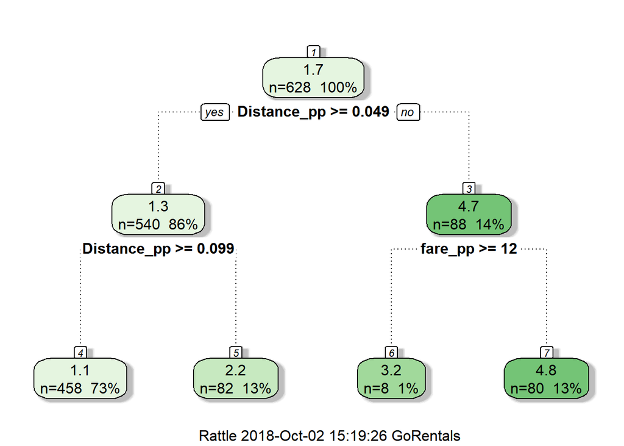

```r
fancyRpartPlot(fitPerPerson)
```

Version 2

```r
dtDataSet <- dPCA.Features
dtDataSet$Distance <- NULL
dtDataSet$fare_amount <- NULL

fitPerPerson <- rpart(dtDataSet$passenger_count ~ ., data = dtDataSet, control = rpart.control(cp = 0.001))
summary(fitPerPerson)
```

```
## Call:
## rpart(formula = dtDataSet$passenger_count ~ ., data = dtDataSet,
##     control = rpart.control(cp = 0.001))
##   n= 628
##
##             CP nsplit  rel error    xerror       xstd
## 1  0.805726153      0 1.00000000 1.0050244 0.08137381
## 2  0.071589167      1 0.19427385 0.2016011 0.02085340
## 3  0.016131074      2 0.12268468 0.1304913 0.01948903
## 4  0.009186037      3 0.10655361 0.1281585 0.01913527
## 5  0.007346843      4 0.09736757 0.1288280 0.01907449
## 6  0.005533176      5 0.09002073 0.1275295 0.01967680
## 7  0.002441389      7 0.07895437 0.1200534 0.01939610
## 8  0.001700658      9 0.07407160 0.1202271 0.01929333
## 9  0.001201827     10 0.07237094 0.1194297 0.01928632
## 10 0.001000000     11 0.07116911 0.1195953 0.01928064
##
## Variable importance
## Distance_pp     fare_pp
##          61          38
##
## Node number 1: 628 observations,    complexity param=0.8057262
##   mean=1.738854, MSE=1.724796
##   left son=2 (540 obs) right son=3 (88 obs)
##   Primary splits:
##       Distance_pp  < 0.04924904 to the right, improve=0.805726200, (0 missing)
##       fare_pp      < 11.91667   to the right, improve=0.591607600, (0 missing)
##       AvgFuelPrice < 3.588539   to the left,  improve=0.018711560, (0 missing)
##       AvgCPI       < 172.8015   to the left,  improve=0.006357240, (158 missing)
##       WeekNo       < 48.5       to the left,  improve=0.005700125, (0 missing)
##   Surrogate splits:
##       fare_pp < 11.16667   to the right, agree=0.943, adj=0.591, (0 split)
##
## Node number 2: 540 observations,    complexity param=0.07158917
##   mean=1.262963, MSE=0.2715912
##   left son=4 (458 obs) right son=5 (82 obs)
##   Primary splits:
##       Distance_pp  < 0.09870855 to the right, improve=0.528731600, (0 missing)
##       fare_pp      < 19.275     to the right, improve=0.394405700, (0 missing)
##       AvgTemp      < 80.53689   to the left,  improve=0.017072260, (0 missing)
```

[output cut: 144 more lines]

```
##
## Node number 35: 14 observations
##   mean=1.928571, MSE=0.06632653
##
## Node number 56: 14 observations
##   mean=4, MSE=0.7142857
##
## Node number 57: 10 observations
##   mean=4.7, MSE=0.61
##
## Node number 68: 60 observations
##   mean=1.033333, MSE=0.03222222
##
## Node number 69: 84 observations
##   mean=1.22619, MSE=0.1750283
```

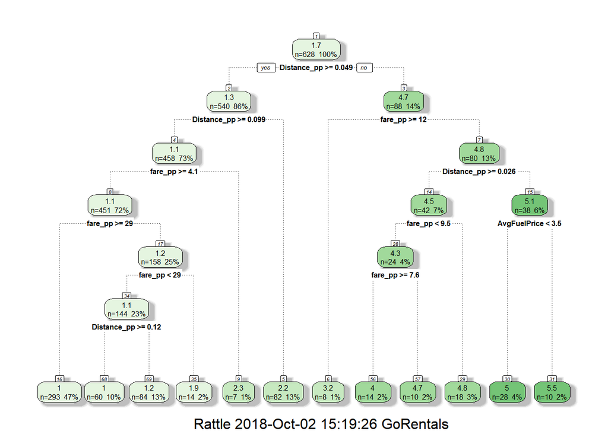

```r
fancyRpartPlot(fitPerPerson)
```

Version 3

```r
dtDataSet <- dPCA.Features
dtDataSet$Distance <- NULL
dtDataSet$Distance_pp <- NULL
dtDataSet$fare_amount <- NULL
dtDataSet$fare_pp <- NULL
dtDataSet$AvgTemp <- NULL

fitPerPerson <- rpart(dtDataSet$passenger_count ~ ., data = dtDataSet, control = rpart.control(cp = 0.001))
summary(fitPerPerson)
```

```
## Call:
## rpart(formula = dtDataSet$passenger_count ~ ., data = dtDataSet,
##     control = rpart.control(cp = 0.001))
##   n= 628
##
##             CP nsplit rel error   xerror       xstd
## 1  0.018711556      0 1.0000000 1.002133 0.08117897
## 2  0.008741784      1 0.9812884 1.012246 0.08237449
## 3  0.005783724      2 0.9725467 1.020361 0.08056803
## 4  0.003725926      3 0.9667629 1.041591 0.08198995
## 5  0.003257659      6 0.9555852 1.053278 0.08276496
## 6  0.001724762     13 0.9327815 1.072532 0.08308105
## 7  0.001709994     14 0.9310568 1.071972 0.08292432
## 8  0.001377857     15 0.9293468 1.075328 0.08329888
## 9  0.001373970     17 0.9265911 1.080493 0.08356091
## 10 0.001263420     19 0.9238431 1.081504 0.08367849
## 11 0.001055998     20 0.9225797 1.081234 0.08364594
## 12 0.001000000     21 0.9215237 1.080193 0.08337972
##
## Variable importance
##    AvgFuelPrice          WeekNo          AvgCPI AvgUnemployment
##              53              30              15               2
## ContainsHoliday
##               1
##
## Node number 1: 628 observations,    complexity param=0.01871156
##   mean=1.738854, MSE=1.724796
##   left son=2 (614 obs) right son=3 (14 obs)
##   Primary splits:
##       AvgFuelPrice    < 3.588539 to the left,  improve=0.018711560, (0 missing)
##       AvgCPI          < 172.8015 to the left,  improve=0.006357240, (158 missing)
##       WeekNo          < 48.5     to the left,  improve=0.005700125, (0 missing)
##       AvgUnemployment < 7.751281 to the right, improve=0.001274261, (158 missing)
##       ContainsHoliday < 0.5      to the right, improve=0.000398872, (0 missing)
##
## Node number 2: 614 observations,    complexity param=0.008741784
##   mean=1.711726, MSE=1.638397
##   left son=4 (422 obs) right son=5 (192 obs)
##   Primary splits:
##       AvgFuelPrice    < 3.368894 to the right, improve=0.0094126100, (0 missing)
```

[output cut: 274 more lines]

```
##       ContainsHoliday < 0.5      to the right, improve=0.0031366730, (0 missing)
##       AvgUnemployment < 7.83277  to the right, improve=0.0006084802, (13 missing)
##   Surrogate splits:
##       WeekNo          < 36.5     to the left,  agree=0.636, adj=0.264, (0 split)
##       AvgCPI          < 172.1515 to the left,  agree=0.636, adj=0.264, (0 split)
##       ContainsHoliday < 0.5      to the right, agree=0.626, adj=0.245, (0 split)
##
## Node number 1125: 46 observations
##   mean=1.76087, MSE=1.35586
##
## Node number 2248: 53 observations
##   mean=1.433962, MSE=0.7739409
##
## Node number 2249: 54 observations
##   mean=1.685185, MSE=1.91941
```

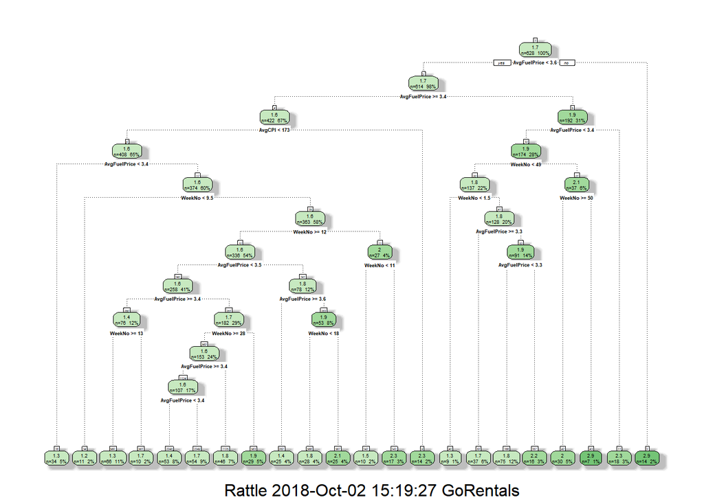

```r
fancyRpartPlot(fitPerPerson)
```

#### Final Model and Evaluation

```r
dtDataSet <- dPCA.Features
dtDataSet$Distance <- NULL
dtDataSet$fare_amount <- NULL

dtTrain <- sample_n(dtDataSet, 440)
dtTest <- sample_n(dtDataSet, 188)

fitPerPerson <- rpart(dtTrain$passenger_count ~ ., data = dtTrain, control = rpart.control(cp = 0.001))
summary(fitPerPerson)
```

```
## Call:
## rpart(formula = dtTrain$passenger_count ~ ., data = dtTrain,
##     control = rpart.control(cp = 0.001))
##   n= 440
##
##            CP nsplit  rel error    xerror       xstd
## 1 0.817938034      0 1.00000000 1.0106584 0.09553671
## 2 0.076299448      1 0.18206197 0.1940958 0.01906954
## 3 0.015257540      2 0.10576252 0.1181651 0.01646620
## 4 0.007567804      3 0.09050498 0.1269193 0.01771741
## 5 0.005936191      4 0.08293717 0.1271922 0.01793037
## 6 0.001499796      6 0.07106479 0.1127871 0.01681820
## 7 0.001317169      7 0.06956500 0.1212085 0.01694451
## 8 0.001275397      9 0.06693066 0.1210952 0.01701247
## 9 0.001000000     10 0.06565526 0.1196953 0.01697685
##
## Variable importance
## Distance_pp     fare_pp
##          59          40
##
## Node number 1: 440 observations,    complexity param=0.817938
##   mean=1.740909, MSE=1.673781
##   left son=2 (377 obs) right son=3 (63 obs)
##   Primary splits:
##       Distance_pp  < 0.04913095 to the right, improve=0.817938000, (0 missing)
##       fare_pp      < 11.91667   to the right, improve=0.610127200, (0 missing)
##       AvgFuelPrice < 3.368894   to the right, improve=0.016938080, (0 missing)
##       AvgTemp      < 62.66342   to the right, improve=0.011570910, (0 missing)
##       WeekNo       < 18.5       to the right, improve=0.007758245, (0 missing)
##   Surrogate splits:
##       fare_pp < 11.558     to the right, agree=0.952, adj=0.667, (0 split)
##
## Node number 2: 377 observations,    complexity param=0.07629945
##   mean=1.262599, MSE=0.2466914
##   left son=4 (317 obs) right son=5 (60 obs)
##   Primary splits:
##       Distance_pp     < 0.09870855 to the right, improve=0.604195300, (0 missing)
##       fare_pp         < 19.205     to the right, improve=0.427713100, (0 missing)
##       AvgUnemployment < 7.790989   to the left,  improve=0.013819620, (88 missing)
##       WeekNo          < 12.5       to the right, improve=0.010094460, (0 missing)
```

[output cut: 132 more lines]

```
##       AvgTemp     < 50.3726    to the right, agree=0.983, adj=0.889, (0 split)
##       WeekNo      < 6.5        to the right, agree=0.931, adj=0.556, (0 split)
##       Distance_pp < 0.1010767  to the right, agree=0.862, adj=0.111, (0 split)
##
## Node number 72: 34 observations
##   mean=1, MSE=0
##
## Node number 73: 10 observations
##   mean=1.4, MSE=0.44
##
## Node number 74: 49 observations
##   mean=1.204082, MSE=0.1624323
##
## Node number 75: 9 observations
##   mean=1.555556, MSE=0.2469136
```

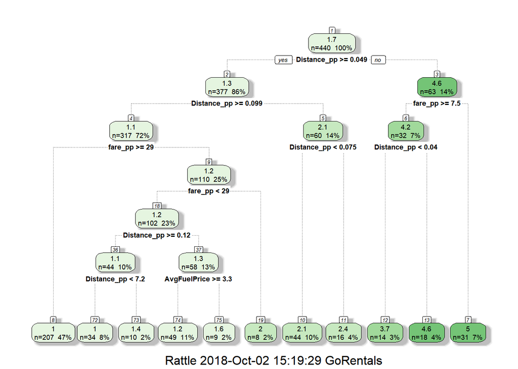

```r
fancyRpartPlot(fitPerPerson)
```

```r
NoOfPassengerPrediction <- predict(fitPerPerson, dtTest)
dtTest$Predicted <- predict(fitPerPerson, dtTest)

dtTest$Difference <- dtTest$passenger_count - dtTest$Predicted
CorrectPredictions <- dtTest[abs(dtTest$Difference) < 0.5, ]
IncorrectPredictions <- dtTest[abs(dtTest$Difference) >= 0.5, ]

Accuracy <- length(CorrectPredictions$Predicted) / length(dtTest$Predicted)
Accuracy
```

```
## [1] 0.8617021
```

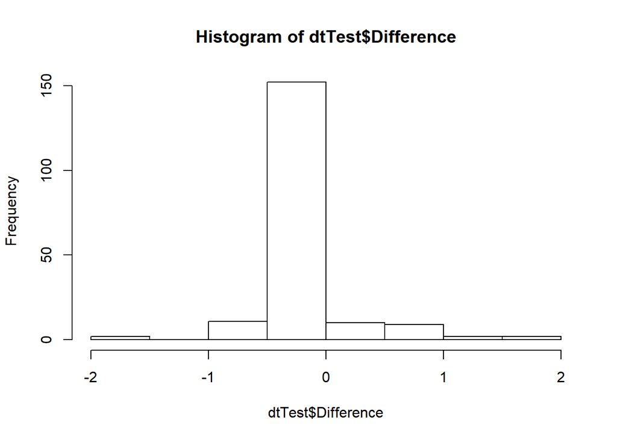

```r
hist(dtTest$Difference)
```

```r
descr(dtTest)
```

```
##
## WeekNo
##    Min. 1st Qu.  Median    Mean 3rd Qu.    Max.
##    1.00   13.00   28.00   26.03   38.00   52.00
##
## passenger_count
##    Min. 1st Qu.  Median    Mean 3rd Qu.    Max.
##   1.000   1.000   1.000   1.723   2.000   6.000
##
## Distance_pp
##     Min.  1st Qu.   Median     Mean  3rd Qu.     Max.
##   0.0191   0.0802   0.1196   4.6568   0.1958 360.3044
##
## fare_pp
##    Min. 1st Qu.  Median    Mean 3rd Qu.    Max.
##    1.50   16.52   28.25   28.47   37.66   79.00
##
## AvgTemp
##    Min. 1st Qu.  Median    Mean 3rd Qu.    Max.
##   35.69   44.43   58.90   59.18   73.83   80.57
##
## AvgFuelPrice
##    Min. 1st Qu.  Median    Mean 3rd Qu.    Max.
##   3.175   3.316   3.396   3.401   3.464   3.589
##
## AvgCPI
##    Min. 1st Qu.  Median    Mean 3rd Qu.    Max.    NA's
##   171.9   172.3   172.8   172.7   173.0   173.6      36
##
## AvgUnemployment
##    Min. 1st Qu.  Median    Mean 3rd Qu.    Max.    NA's
##   7.559   7.744   7.744   7.784   7.921   7.937      36
##
## ContainsHoliday
##    Min. 1st Qu.  Median    Mean 3rd Qu.    Max.
## 0.00000 0.00000 0.00000 0.07979 0.00000 1.00000
##
## Predicted
##    Min. 1st Qu.  Median    Mean 3rd Qu.    Max.
##   1.000   1.014   1.014   1.734   2.068   5.032
##
## Difference
##     Min.  1st Qu.   Median     Mean  3rd Qu.     Max.
## -1.55556 -0.06818 -0.01449 -0.01066 -0.01449  1.93182
```